# Private (and other) schools

JL-Herrera

2025-04-01

## School districts

Using the data extracted from the TEA we get [school district boundaries](https://schoolsdata2-tea-texas.opendata.arcgis.com).

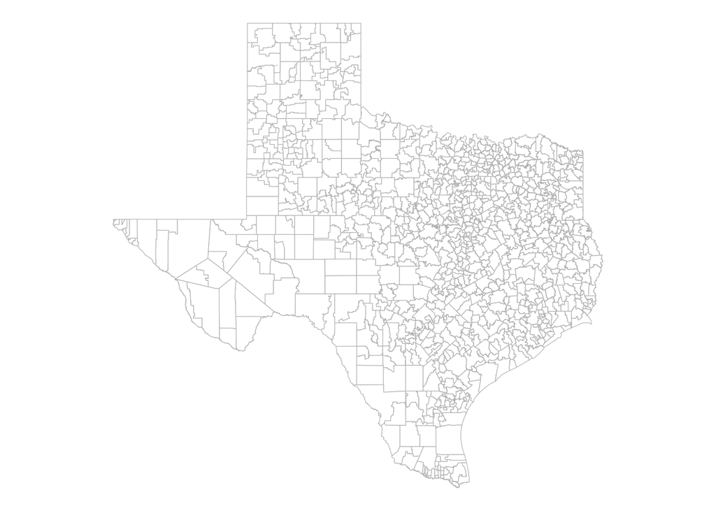

```r
###  ------

#Data extracted from: https://schoolsdata2-tea-texas.opendata.arcgis.com
#Following the link "current districts"
#https://schoolsdata2-tea-texas.opendata.arcgis.com/datasets/edbb3c145304494382da3aa30c154b5e/explore?showTable=true
school_districts_map_original <- read_sf("Data/school_districts/Current_Districts_2025/Current_Districts_2025.shp")

ggplot() + theme_void() +
  geom_sf(data=school_districts_map_original,fill="white",color="gray")
```

## Risk data

Here I create two data frames. One with all districts (risk_eval_clean_with_counties), and one with non-SD districts (risk_non_SD_schools).

```
## # A tibble: 6 × 5
##   County SchoolDistrict_or_Name              metric              for500 ageGroup
##   <chr>  <chr>                               <chr>                <dbl> <chr>
## 1 DALLAS A W BROWN LEADERSHIP ACADEMY        probability_exceed…  0.854 Kinderg…
## 2 DALLAS A+ ACADEMY                          probability_exceed…  0     Kinderg…
## 3 HARRIS ACADEMY OF ACCELERATED LEARNING INC probability_exceed…  0.619 Kinderg…
## 4 HARRIS ACCELERATED INTERMEDIATE ACADEMY    probability_exceed…  0.342 Kinderg…
## 5 DALLAS ADVANTAGE ACADEMY                   probability_exceed…  0.012 Kinderg…
## 6 TRAVIS AESA PREP ACADEMY                   probability_exceed…  0.864 Kinderg…
```

### Kindergarten

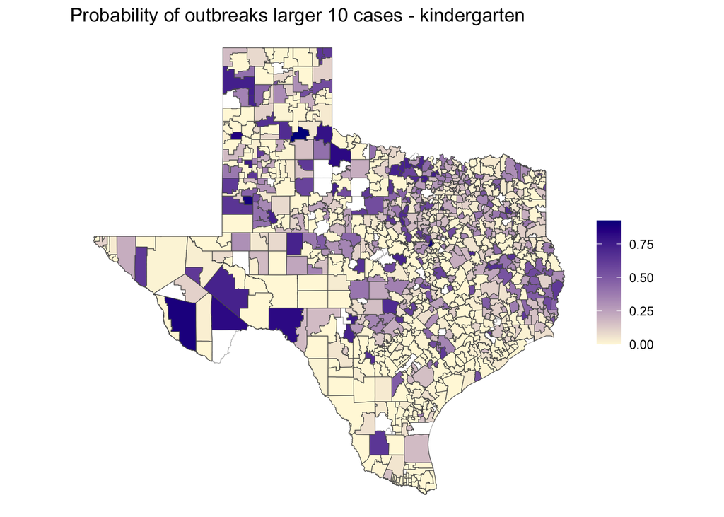

```r
risk_eval_kindergarten<-risk_eval_clean_with_counties %>%
  filter(ageGroup=="Kindergarten")

#Homogenization of names
# to upper all letters in names:
school_districts_map<-school_districts_map_original %>% select(NAME) %>%
  mutate(NAME=toupper(NAME))
risk_eval_kindergarten<-risk_eval_kindergarten %>%
  select(County,NAME=SchoolDistrict_or_Name,metric,for500) %>%
  mutate(NAME=toupper(NAME))

#Changing only one case in map data
school_districts_map<-school_districts_map %>%
  mutate(NAME=NAME %>% str_replace_all(c("CONSOLIDATED"="CONS")))

#Changing in risk from CISD to CONS ISD to match with map
risk_eval_kindergarten<- risk_eval_kindergarten %>% filter(str_detect(NAME,"SD")) %>%
  mutate(NAME=NAME %>% str_replace_all(c("CISD"="CONS ISD",
                                         "MT-SAGINAW"="MOUNTAIN-SAGINAW",
                                         "FT SAM"="FORT SAM",
                                         "GOLD BURG"="GOLD-BURG",
                                         "CONSOLIDATED"="CONS",
                                         "FT DAVIS"="FORT DAVIS",
                                         "FT HANCOCK"="FORT HANCOCK",
                                         "COUNTY WIDE"="COUNTY-WIDE",
                                         "SCHERTZ-CIBOLO-U CITY ISD"="SCHERTZ-CIBOLO-UNIVERSAL CITY ISD")))

#To add school districts with the same name in different counties
risk_eval_kindergarten<-risk_eval_kindergarten %>%
  mutate(NAME=ifelse(NAME=="BIG SANDY ISD",paste0(NAME," (",County,")"),NAME)) %>%
  mutate(NAME=ifelse(NAME=="CHAPEL HILL ISD",paste0(NAME," (",County,")"),NAME)) %>%
  mutate(NAME=ifelse(NAME=="CENTERVILLE ISD",paste0(NAME," (",County,")"),NAME)) %>%
  mutate(NAME=ifelse(NAME=="DAWSON ISD",paste0(NAME," (",County,")"),NAME)) %>%
  mutate(NAME=ifelse(NAME=="EDGEWOOD ISD",paste0(NAME," (",County,")"),NAME)) %>%
  mutate(NAME=ifelse(NAME=="HIGHLAND PARK ISD",paste0(NAME," (",County,")"),NAME)) %>%
  mutate(NAME=ifelse(NAME=="HUBBARD ISD",paste0(NAME," (",County,")"),NAME)) %>%
  mutate(NAME=ifelse(NAME=="MIDWAY ISD",paste0(NAME," (",County,")"),NAME)) %>%
  mutate(NAME=ifelse(NAME=="NORTHSIDE ISD",paste0(NAME," (",County,")"),NAME)) %>%
  mutate(NAME=ifelse(NAME=="VALLEY VIEW ISD",paste0(NAME," (",County,")"),NAME)) %>%
  mutate(NAME=ifelse(NAME=="WYLIE ISD",paste0(NAME," (",County,")"),NAME))

#risk_eval_kindergarten$metric %>% unique()

data_prob_kinder<-school_districts_map %>%
  left_join(risk_eval_kindergarten %>% select(-County)) %>%
  filter(metric=="probability_exceeding_10_total_cases") %>%
  filter(NAME!="ROSCOE COLLEGIATE ISD")
ggplot() +
  geom_sf(data=school_districts_map_original,fill="white",color="gray") +
  geom_sf(data=data_prob_kinder,aes(fill=for500)) + theme_void() +
  scale_fill_gradient(low = "cornsilk1",high = "blue4",name="") +
  ggtitle("Probability of outbreaks larger 10 cases - kindergarten")
```

### Seventh grade

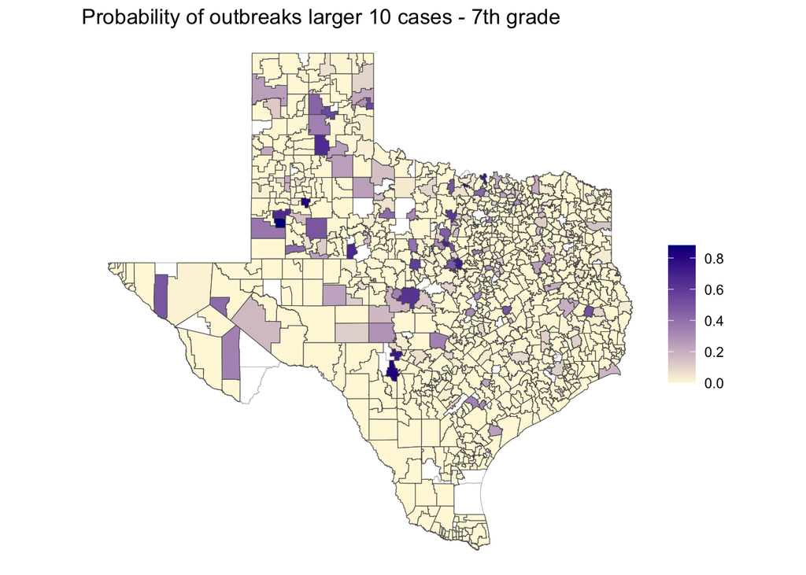

```r
risk_eval_seventh<-risk_eval_clean_with_counties %>%
  filter(ageGroup=="7th Grade")

#Homogenization of names
# to upper all letters in names:
school_districts_map<-school_districts_map %>% select(NAME) %>%
  mutate(NAME=toupper(NAME))
risk_eval_seventh<-risk_eval_seventh %>%
  select(County,NAME=SchoolDistrict_or_Name,metric,for500) %>%
  mutate(NAME=toupper(NAME))

#Changing only one case in map data
school_districts_map<-school_districts_map %>%
  mutate(NAME=NAME %>% str_replace_all(c("CONSOLIDATED"="CONS")))

#Changing in risk from CISD to CONS ISD to match with map
risk_eval_seventh<- risk_eval_seventh %>% filter(str_detect(NAME,"SD")) %>%
  mutate(NAME=NAME %>% str_replace_all(c("CISD"="CONS ISD",
                                         "MT-SAGINAW"="MOUNTAIN-SAGINAW",
                                         "FT SAM"="FORT SAM",
                                         "GOLD BURG"="GOLD-BURG",
                                         "CONSOLIDATED"="CONS",
                                         "FT DAVIS"="FORT DAVIS",
                                         "FT HANCOCK"="FORT HANCOCK",
                                         "COUNTY WIDE"="COUNTY-WIDE",
                                         "SCHERTZ-CIBOLO-U CITY ISD"="SCHERTZ-CIBOLO-UNIVERSAL CITY ISD")))

#To add school districts with the same name in different counties
risk_eval_seventh<-risk_eval_seventh %>%
  mutate(NAME=ifelse(NAME=="BIG SANDY ISD",paste0(NAME," (",County,")"),NAME)) %>%
  mutate(NAME=ifelse(NAME=="CHAPEL HILL ISD",paste0(NAME," (",County,")"),NAME)) %>%
  mutate(NAME=ifelse(NAME=="CENTERVILLE ISD",paste0(NAME," (",County,")"),NAME)) %>%
  mutate(NAME=ifelse(NAME=="DAWSON ISD",paste0(NAME," (",County,")"),NAME)) %>%
  mutate(NAME=ifelse(NAME=="EDGEWOOD ISD",paste0(NAME," (",County,")"),NAME)) %>%
  mutate(NAME=ifelse(NAME=="HIGHLAND PARK ISD",paste0(NAME," (",County,")"),NAME)) %>%
  mutate(NAME=ifelse(NAME=="HUBBARD ISD",paste0(NAME," (",County,")"),NAME)) %>%
  mutate(NAME=ifelse(NAME=="MIDWAY ISD",paste0(NAME," (",County,")"),NAME)) %>%
  mutate(NAME=ifelse(NAME=="NORTHSIDE ISD",paste0(NAME," (",County,")"),NAME)) %>%
  mutate(NAME=ifelse(NAME=="VALLEY VIEW ISD",paste0(NAME," (",County,")"),NAME)) %>%
  mutate(NAME=ifelse(NAME=="WYLIE ISD",paste0(NAME," (",County,")"),NAME))

#There are 3 ISDs that are in the risk file, but not in the school map
#setdiff(risk_eval_seventh$NAME,school_districts_map$NAME)

data_prob_seventh<-school_districts_map %>%
  left_join(risk_eval_seventh) %>%
  filter(metric=="probability_exceeding_10_total_cases") %>%
  filter(NAME!="ROSCOE COLLEGIATE ISD")
ggplot() + theme_void() +
  geom_sf(data=school_districts_map_original,fill="white",color="gray") +
  geom_sf(data=data_prob_seventh,aes(fill=for500)) +
  scale_fill_gradient(low = "cornsilk1",high = "blue4",name="") +
  ggtitle("Probability of outbreaks larger 10 cases - 7th grade")
```

## Private schools and other

Shape file for schools for enrollment 2023-2024 can be obtained [here](https://schoolsdata2-tea-texas.opendata.arcgis.com/datasets/TEA-Texas::schools-2023-to-2024/explore?location=29.472835%2C-99.372450%2C6.30&showTable=true). It contains a huge amount of information. I select columns that show: county, district name, and school name. Additinally, since I am interested in schools I filter out all those districts that included “SD” as the las two letters in their name (ISD, CSD, and so on).

```r
schools2023<-read_sf("Data/Schools_2023_to_2024/Schools_2023_to_2024.shp")

#This includes all schools that "might" have kindergarten's
#Also, I am using district and name of school columns, since the risk data
#mixes both in the name column
privateSchools_kinder<-schools2023 %>%
  filter(School_Typ %in% c("Elementary School","Elementary/Secondary")) %>%
  select(County=Subregion,Grade_range=USER_Grade,
         District_ISD=USER_Dis_1,School_name=USER_Sch_1,School_enroll_2023=USER_Sch15) %>%
  #filter(School_enroll_2023>0) %>%
  filter(!grepl("SD$", District_ISD)) %>%
  select(County,District_ISD,School_name,School_enroll_2023) %>% mutate(County=County %>% str_remove_all(" County")) %>%
  mutate(County=toupper(County),District_ISD=toupper(District_ISD),ageGroup="Kindergarten",School_name=toupper(School_name)) %>%
  arrange(District_ISD) %>% drop_na() %>% unique()

privateSchools_kinder %>% head()
```

```
## Simple feature collection with 6 features and 5 fields
## Geometry type: POINT
## Dimension:     XY
## Bounding box:  xmin: -96.88159 ymin: 29.66806 xmax: -95.31105 ymax: 32.76949
## Geodetic CRS:  WGS 84
## # A tibble: 6 × 6
##   County District_ISD   School_name School_enroll_2023             geometry
##   <chr>  <chr>          <chr>                    <int>          <POINT [°]>
## 1 DALLAS A W BROWN LEA… QUEST CAMP…                435 (-96.88159 32.67784)
## 2 DALLAS A W BROWN LEA… GENESIS CA…                343 (-96.88159 32.67784)
## 3 DALLAS A+ ACADEMY     A+ ACADEMY…                897  (-96.6452 32.69295)
## 4 DALLAS ACADEMY FOR A… DALLAS COU…                213 (-96.86673 32.76949)
## 5 HARRIS ACADEMY OF AC… ACADEMY OF…                830 (-95.31105 29.66806)
## 6 DALLAS ACADEMY OF DA… ACADEMY OF…                354 (-96.83617 32.72294)
## # ℹ 1 more variable: ageGroup <chr>
```

I assumed (wrongly) that since private schools do not belong to a school district, then district and school would be unique. However, this is not the case. Additionally, some of the districts in the risk data are not actually districts. The issue is that these districts are not contiguous regions. For example,

```r
privateSchools_kinder %>% as_tibble() %>% select(County,District_ISD) %>% group_by(County,District_ISD) %>% count() %>% arrange(desc(n))
```

```
## # A tibble: 314 × 3
## # Groups:   County, District_ISD [314]
##    County  District_ISD                    n
##    <chr>   <chr>                       <int>
##  1 HIDALGO IDEA PUBLIC SCHOOLS            29
##  2 BEXAR   IDEA PUBLIC SCHOOLS            25
##  3 HARRIS  YES PREP PUBLIC SCHOOLS INC    21
##  4 DALLAS  UPLIFT EDUCATION               13
##  5 HARRIS  KIPP TEXAS PUBLIC SCHOOLS      13
##  6 CAMERON IDEA PUBLIC SCHOOLS            11
##  7 TRAVIS  IDEA PUBLIC SCHOOLS            10
##  8 BEXAR   GREAT HEARTS TEXAS              8
##  9 TARRANT UPLIFT EDUCATION                8
## 10 BEXAR   BASIS TEXAS                     6
## # ℹ 304 more rows
```

which shows that the district “IDEA PUBLIC SCHOOLS” has 29 schools in Hidalgo County.

```r
privateSchools_kinder %>% as_tibble() %>% select(County,District_ISD,School_name,School_enroll_2023) %>%
  filter(District_ISD=="IDEA PUBLIC SCHOOLS",County=="HIDALGO")
```

```
## # A tibble: 29 × 4
##    County  District_ISD        School_name                    School_enroll_2023
##    <chr>   <chr>               <chr>                                       <int>
##  1 HIDALGO IDEA PUBLIC SCHOOLS IDEA QUEST COLLEGE PREPARATORY                678
##  2 HIDALGO IDEA PUBLIC SCHOOLS IDEA COLLEGE PREPARATORY SAN …                736
##  3 HIDALGO IDEA PUBLIC SCHOOLS IDEA COLLEGE PREPARATORY ALAMO                763
##  4 HIDALGO IDEA PUBLIC SCHOOLS IDEA COLLEGE PREP                             785
##  5 HIDALGO IDEA PUBLIC SCHOOLS IDEA COLLEGE PREPARATORY MISS…                772
##  6 HIDALGO IDEA PUBLIC SCHOOLS IDEA COLLEGE PREP WESLACO                     756
##  7 HIDALGO IDEA PUBLIC SCHOOLS IDEA EDINBURG COLLEGE PREPARA…                779
##  8 HIDALGO IDEA PUBLIC SCHOOLS IDEA MCALLEN COLLEGE PREPARAT…                807
##  9 HIDALGO IDEA PUBLIC SCHOOLS IDEA COLLEGE PREPARATORY PHARR                863
## 10 HIDALGO IDEA PUBLIC SCHOOLS IDEA WESLACO PIKE COLLEGE PRE…                749
## # ℹ 19 more rows
```

The problem is that these schools are not in a given region, they are distributed around Hidalgo (we can calculate the distance between them using the coordinates, or just verify this in google maps). Now, in the risk data, “IDEA PUBLIC SCHOOLS” is considered as one contiguous district

```r
risk_eval_clean_with_counties %>% filter(str_detect(SchoolDistrict_or_Name,"IDEA PUBLIC SCHOOLS")) %>%
  filter(metric=="probability_exceeding_10_total_cases",ageGroup=="Kindergarten",County=="HIDALGO")
```

```
## # A tibble: 1 × 5
##   County  SchoolDistrict_or_Name metric                          for500 ageGroup
##   <chr>   <chr>                  <chr>                            <dbl> <chr>
## 1 HIDALGO IDEA PUBLIC SCHOOLS    probability_exceeding_10_total…  0.007 Kinderg…
```

This issue happens with many of the non-SD districts and private schools. I did this for 7th grade too, and get the location of schools in Texas.

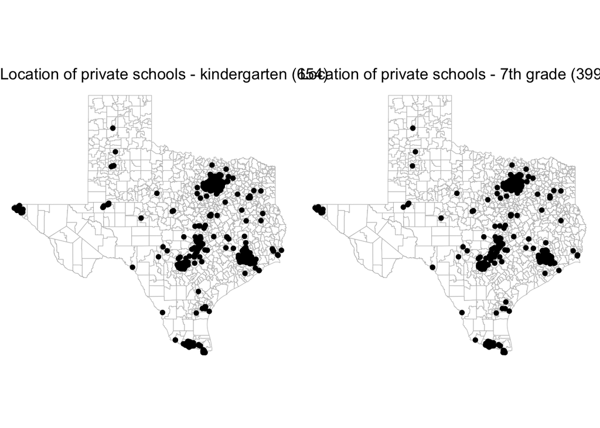

```r
#This includes all middle/junior/secondary that have a 7th grade
seventh_stu_1<-schools2023 %>% filter(School_Typ %in% c("Middle School","Junior High School","Elementary/Secondary")) %>%
  select(County=Subregion,Grade_range=USER_Grade,District_ISD=USER_Dis_1,School_name=USER_Sch_1) %>%
  filter(!Grade_range %in% c("06","08-09","08","PK 09-12","EE 09-12")) %>%
  filter(!grepl("SD$", District_ISD))

#This includes all high schools with 7th grade
seventh_stu_2<-schools2023 %>% filter(School_Typ=="High School") %>%
  select(County=Subregion,Grade_range=USER_Grade,District_ISD=USER_Dis_1,School_name=USER_Sch_1) %>%
  filter(str_detect(Grade_range,"07")) %>% filter(!grepl("SD$", District_ISD))

#This includes all private schools that may contain 7th grade students
privateSchools_seventh<-bind_rows(seventh_stu_1,seventh_stu_2) %>%
  select(County,District_ISD,School_name) %>% mutate(County=County %>% str_remove_all(" County")) %>%
  mutate(County=toupper(County),District_ISD=toupper(District_ISD),School_name=toupper(School_name),ageGroup="7th Grade") %>%
  drop_na() %>% unique()

#Location of all private school that "might" have kindergarten students
all_schools_kinder_nonSD<-ggplot() + theme_void() +
  geom_sf(data=school_districts_map_original,fill="white",color="gray") +
  geom_sf(data=privateSchools_kinder) +
  ggtitle("Location of private schools - kindergarten (654)")

#Location of all private school that 7th grade
all_schools_seventh_nonSD<-ggplot() + theme_void() +
  geom_sf(data=school_districts_map_original,fill="white",color="gray") +
  geom_sf(data=privateSchools_seventh) +
  ggtitle("Location of private schools - 7th grade (399)")

plot_grid(all_schools_kinder_nonSD,all_schools_seventh_nonSD)
```

### Combining schools with risk

Now, to build a simple and first version of the maps showing risk in districts and “private” schools I decided to keep only one of those schools in the school data, and merge with risk data.

```r
# For kindergarten

#Merging with District
by_district_kinder<-privateSchools_kinder %>% select(-School_name) %>%
  mutate(countyAndName=paste0(County,"-",District_ISD)) %>%
  group_by(countyAndName) %>% slice(1) %>% arrange(District_ISD)
#Merging with school name
by_school_kinder<-privateSchools_kinder %>% select(-District_ISD) %>%
  mutate(countyAndName=paste0(County,"-",School_name)) %>%
  group_by(countyAndName) %>% slice(1) %>% arrange(School_name)

estos_risk_kinder <- risk_non_SD_schools %>% filter(ageGroup=="Kindergarten") %>%
  filter(metric=="probability_exceeding_10_total_cases") %>%
  select(-metric,-ageGroup) %>%
  mutate(countyAndName=paste0(County,"-",SchoolDistrict_or_Name)) %>% unique()

ver_1<-by_district_kinder %>%
  merge(estos_risk_kinder %>% select(for500,countyAndName), by="countyAndName") %>%
  rename_at("District_ISD",~"NAME")
ver_2<-by_school_kinder %>%
  merge(estos_risk_kinder %>% select(for500,countyAndName), by="countyAndName") %>%
  rename_at("School_name",~"NAME")

#bind_rows(ver_1,ver_2) %>% pull(countyAndName) %>% table() %>% as_tibble() %>% arrange(desc(n)) %>% print(n=40)

all_private_schools_kinder<-bind_rows(ver_1,ver_2) %>% unique()

#### For 7th grade

#Merging with District
by_district_seventh<-privateSchools_seventh %>% select(-School_name) %>%
  mutate(countyAndName=paste0(County,"-",District_ISD)) %>%
  group_by(countyAndName) %>% slice(1) %>% arrange(District_ISD) %>% unique()

#Merging with school name
by_school_seventh<-privateSchools_seventh %>% select(-District_ISD) %>%
  mutate(countyAndName=paste0(County,"-",School_name)) %>%
  group_by(countyAndName) %>% slice(1) %>% arrange(School_name) %>% unique()

estos_risk_seventh <- risk_non_SD_schools %>% filter(ageGroup=="7th Grade") %>%
  filter(metric=="probability_exceeding_10_total_cases") %>%
  select(-metric,-ageGroup) %>%
  mutate(countyAndName=paste0(County,"-",SchoolDistrict_or_Name)) %>% unique()

ver_1_seventh<-by_district_seventh %>%
  merge(estos_risk_seventh %>% select(for500,countyAndName), by="countyAndName") %>%
  rename_at("District_ISD",~"NAME")
ver_2_seventh<-by_school_seventh %>%
  merge(estos_risk_seventh %>% select(for500,countyAndName), by="countyAndName") %>%
  rename_at("School_name",~"NAME")

#bind_rows(ver_1_seventh,ver_2_seventh) %>% pull(countyAndName) %>% table() %>% as_tibble() %>% arrange(desc(n)) %>% print(n=40)

all_private_schools_seventh<-bind_rows(ver_1_seventh,ver_2_seventh) %>% unique()
```

And finally, the maps for kindergarten and 7th grade look like this

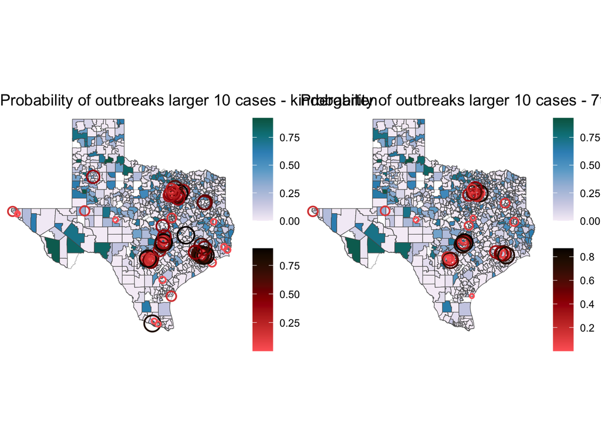

```r
kinder_private_schools<-ggplot() +
geom_sf(data=school_districts_map_original,fill="white",color="gray") +
  geom_sf(data=data_prob_kinder,aes(fill=for500)) + theme_void() +
    #scale_fill_gradientn(colors = c("#f7f7f7", "#d8b365", "#5ab4ac", "#01665e"),name="")+
  scale_fill_distiller(palette = "PuBuGn", direction = 1,name="") +
#  scale_fill_gradient(low = "cornsilk1",high = "blue4",name="") +
  geom_sf(data=all_private_schools_kinder %>% filter(for500>0),
          aes(size=for500,color=for500),shape=1,stroke=1)+
  scale_color_gradientn(colors = c("#ff6666", "#990000", "#000000"),name="") +
#  scale_color_gradientn(colors = c("#fdae61", "#d73027", "#67000d"),name="")+
#  scale_color_gradient(high = "black",low = "#B4464B",name="") +
  ggtitle("Probability of outbreaks larger 10 cases - kindergarten")+
  guides(size = "none")

seventh_private_schools<-ggplot() +
  geom_sf(data=school_districts_map_original,fill="white",color="gray") +
  geom_sf(data=data_prob_kinder,aes(fill=for500)) + theme_void() +
  #scale_fill_gradientn(colors = c("#f7f7f7", "#d8b365", "#5ab4ac", "#01665e"),name="")+
  scale_fill_distiller(palette = "PuBuGn", direction = 1,name="") +
  #  scale_fill_gradient(low = "cornsilk1",high = "blue4",name="") +
  geom_sf(data=all_private_schools_seventh %>% filter(for500>0),
          aes(size=for500,color=for500),shape=1,stroke=1)+
  scale_color_gradientn(colors = c("#ff6666", "#990000", "#000000"),name="") +
  #  scale_color_gradientn(colors = c("#fdae61", "#d73027", "#67000d"),name="")+
  #  scale_color_gradient(high = "black",low = "#B4464B",name="") +
  ggtitle("Probability of outbreaks larger 10 cases - 7th grade")+
  guides(size = "none")

plot_grid(kinder_private_schools,seventh_private_schools)
```